*After ten cycles of the golden search we get to an interval smaller than 0.001 and the maximum value of cell growth is reached at a sugar concentration of 93.6%. This will be enough detail to set the best nutrient concentration for bacterial growth in our medium.*

Simple differentiable functions like the one in the example above can also be optimized “manually” using calculus, but often times we’ll find ourselves with complex models, or with more than one input variable, which can be optimized with other methods such as [Gradient Descent](https://machinelearningmastery.com/a-gentle-introduction-to-gradient-descent-procedure/)

## 4: Stochastic Algorithms

As we have seen in the last section, when a scoring function can be derivated, we can use that gradient to find and follow the trend of a function towards a maximum or minimum. But what do we do if our scoring function:

- Would take way too much time or computational power to be optimized by deterministic methods.
- Has multiple local optima that would be good enough for our needs and easier to find.
- The target function we want to optimize is susceptible to noise or has too many local maximums or minimums, so deterministic methods might have trouble getting stuck.

In cases like this we can benefit from optimization methods that include some *randomness* into the process. This randomness can be achieved through several ways, like drawing parameter values from a probabilistic distribution, or making small random changes in each iteration.

This means that given the same data, stochastic algorithms might explore different possibilities in every run. These algorithms won’t test the whole range of possible solutions exhaustively, and don’t offer guarantees that the solution found is a global optimum, but their heuristic approach makes partial solutions available for complex situations that can’t be optimized in a reasonable time with other methods.

We’ll illustrate briefly with an example the basis of some of the most popular stochastic optimization methods: **evolutionary algorithms**.

Evolutionary algorithms aim to replicate the success of **natural selection** in finding *good enough* solutions. As many optimization algorithms, evolutionary algorithms are iterative in nature: part of their structure is a cycle repeated time and time again until the models are *good enough* for the user, or a limit is reached.

This iterative structure is very reminiscent of how living organisms reproduce, and change every generation as the better adapted populations thrive and others dwindle. How can we reproduce this selection process in an optimization algorithm? Evolutionary algorithms often follow this steps:

- They are **population** based algorithms: since the start, we will have a set of possible solutions to the function we want to optimize.
- In each generation the different solutions **compete**: the possible solutions will be evaluated, the best ones will be kept, and the worst, discarded
- Each cycle, the new generation of possible solutions if built from the best performing possibilities of the last cycle.
- In order to introduce variation and avoid getting stuck in a local optimum, evolutionary algorithms adapt mechanisms such as **recombinations** or **mutations**.

*Let’s say we are developing an early diagnostic protocol for a disease:*  
- *In the literature available there are described numerous polymorphisms linked to this disease to varying degrees, but all of them are also present in the general population*.  
- *Besides a list of polymorphisms, we have an independent sequencing study done in a patient cohort as well as healthy subjects, that indicates if a particular polymorphism is present or not.*  
- *Our specific goal would be to develop a predictive model from polymorphism data, so that is possible to detect susceptible individuals by sequencing a few small specific regions of the genome. If the treatment is not innocuous on healthy subjects, we would need to heavily penalize false positives. Additionally, depending on how costly the sequencing process is, models that need fewer polymorphisms to make accurate predictions would be favored. All of this limitations are what define our **scoring function***

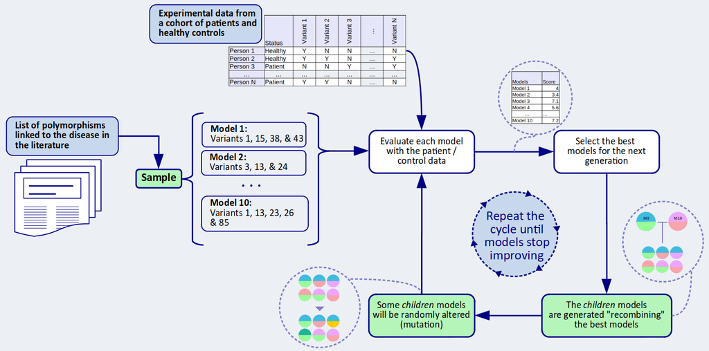

In the chart above there’s a summary of the optimization procedure, with the sources of **stochastic variation** in green:

- First, to create our initial generation of predictive models, we can take several random samples of the polymorphisms linked to our disease.
- Then, using the sequencing study and our scoring function, we evaluate the first generation of models and select the best of them.
- The second generation will be generated by randomly combining (*recombining*) polymorphisms used by the best *parents*.
- Some of the children models will be altered further to introduce some additional variation (*mutation*).
- The second generation is evaluated, and the cycle goes on.

Over time the models will end up converging into a combination of polymorphisms that are **well adapted** to the conditions of our scoring function: detect at risk people, avoid false positives, and use a small number of polymorphisms.

**More resources**

- [Become the algorithm!](https://phylo.cs.mcgill.ca/) This game will challenge you with multiple sequence alignment puzzles. While you play, think about how are you making the choices to move the sequences around in order to maximize your score.
- Another example of a deterministic algorithm, [Intro to optimization in deep learning: Gradient Descent](https://blog.paperspace.com/intro-to-optimization-in-deep-learning-gradient-descent/)
- [A Gentle Introduction to Stochastic Optimization Algorithms](https://machinelearningmastery.com/stochastic-optimization-for-machine-learning/)